# Corona - Tagesreport

## Infos zum Bericht

### Abrufzeitpunkt

| Amtliche RKI-Corona-Daten für Land-/Stadtkreis | Abrufzeitpunkt |
| --- | --- |
| Kreisfreie Stadt Passau | Dienstag, 11.05.2021, 02:16:58 |

### Inzidenzrelevanter Zeitraum

| von - bis | nicht mehr in der Inzidenzzahl |
| --- | --- |
| Di, 04.05.2021 - Mo, 10.05.2021 | Mo, 03.05.2021 und älter |

### Datenbeschreibung

[Link zur Datenbeschreibung des RKI](https://www.arcgis.com/home/item.html?id=dd4580c810204019a7b8eb3e0b329dd6)

## Diagramme

### Wochenübersicht

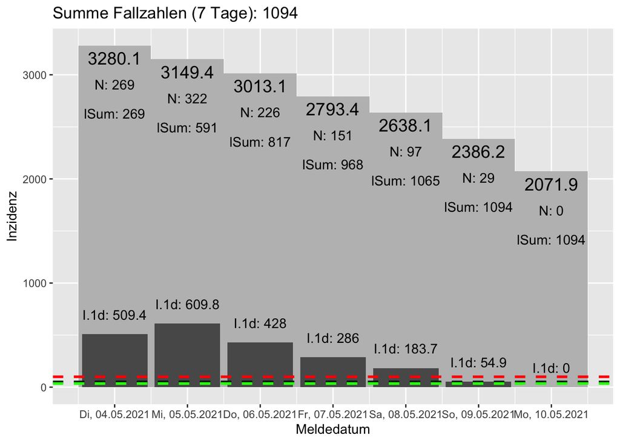

Erläuterung der Zahlenangaben:  
**N**: Anzahl der neu und nachträglich gemeldeten abzüglich der gestrichenen Fälle des jeweiligen Tages  
**I.1d** (“1-Tages-Inzidenz”): Höhe des Beitrags, den dieser Tag zur Wocheninzidenz leistet  
**lSum**: Aggregierte Summe der Fallzahlen über den Verlauf der beobachteten Woche. Der erste Tag entspricht diesem einzelnen Tag (und fällt als nächstes aus der Inzidenz), der letzte Tag entspricht der Wochen-Inzidenz.

### Inzidenzverlauf

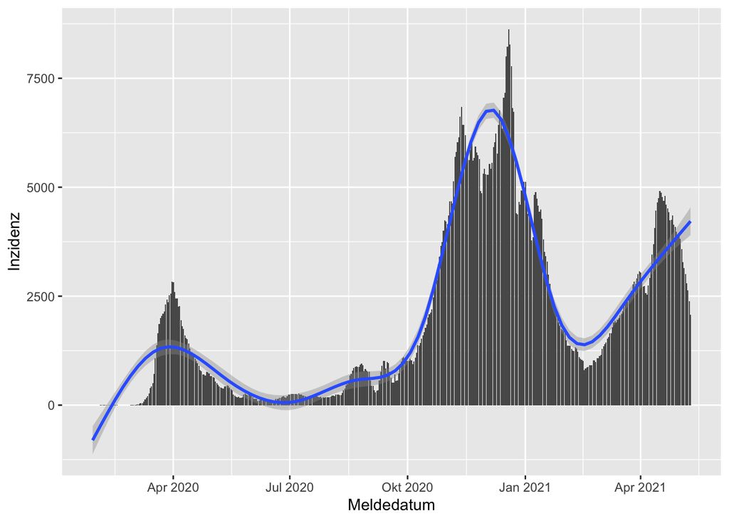

### Neu gemeldete Fälle je Tag

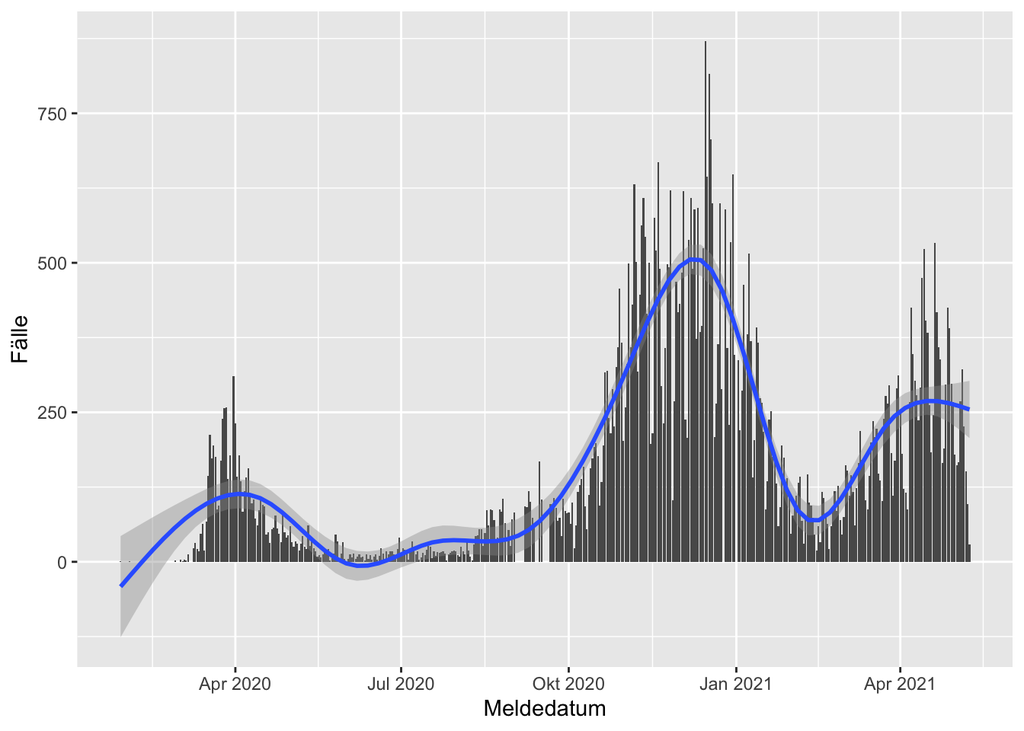

### Neu gemeldete Fälle je Tag in 2021

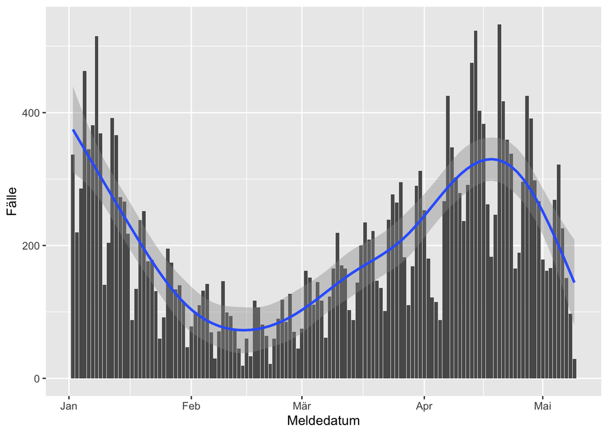

## Details zu Inzidenz und Altersstruktur

### Heute neu

| Meldedatum | Art | Inzidenzrelevant | Fallzahl | A00-A04 | A05-A14 | A15-A34 | A35-A59 | A60-A79 | A80+ |
| --- | --- | --- | --- | --- | --- | --- | --- | --- | --- |
| 2021-04-17 | Neu | Nein | 1 | 0 | 0 | 1 | 0 | 0 | 0 |
| 2021-04-18 | Storno | Nein | -1 | 0 | 0 | 0 | 0 | -1 | 0 |
| 2021-04-26 | Neu | Nein | 1 | 0 | 0 | 1 | 0 | 0 | 0 |
| 2021-04-26 | Storno | Nein | -2 | -1 | 0 | -1 | 0 | 0 | 0 |
| 2021-04-30 | Neu | Nein | 3 | 0 | 0 | 1 | 2 | 0 | 0 |
| 2021-05-03 | Neu | Nein | 1 | 0 | 0 | 1 | 0 | 0 | 0 |
| 2021-05-03 | Storno | Nein | -1 | 0 | 0 | 0 | -1 | 0 | 0 |
| 2021-05-04 | Neu | Ja | 4 | 0 | 1 | 1 | 2 | 0 | 0 |
| 2021-05-05 | Neu | Ja | 5 | 1 | 1 | 1 | 1 | 1 | 0 |
| 2021-05-05 | Storno | Ja | -1 | 0 | 0 | -1 | 0 | 0 | 0 |
| 2021-05-06 | Neu | Ja | 2 | 1 | 1 | 0 | 0 | 0 | 0 |
| 2021-05-07 | Neu | Ja | 2 | 0 | 0 | 2 | 0 | 0 | 0 |
| 2021-05-08 | Neu | Ja | 31 | 1 | 4 | 18 | 5 | 3 | 0 |
| 2021-05-08 | Storno | Ja | -3 | 0 | 0 | -1 | -1 | -1 | 0 |
| 2021-05-09 | Neu | Ja | 29 | 1 | 1 | 11 | 12 | 3 | 1 |

### Altersstruktur

“Kohorteninzidenz” steht für die getrennt nach Altersgruppen (“Kohorten”) ausgewiesene 7-Tage-Inzidenz. Diese wird von RKI bislang nicht veröffentlicht, da hierfür die lokale Altersstruktur bekannt sein muss.

|  | A00-A04 | A05-A14 | A15-A34 | A35-A59 | A60-A79 | A80+ |
| --- | --- | --- | --- | --- | --- | --- |
| Fälle | 36 | 92 | 398 | 456 | 96 | 15 |
| EWO | 2138 | 3180 | 15820 | 16601 | 11298 | 3744 |
| Kohorteninzidenz | 1683.8 | 2893.1 | 2515.8 | 2746.8 | 849.7 | 400.6 |

### Grenzwerte

“max. Fallzahl” steht für die höchste Fallzahl, die den jeweiligen Grenzwert noch einhält. “Abweichung” beschreibt, wie weit man über oder unter dieser Fallzahl liegt (“0” ist somit die Punktlandung).

BITTE BEACHTEN: Die Anzahl der Tage, seit denen ein Schwellenwert unterschritten wird, kann auf zweierlei Wegen bestimmt werden:

- bezogen auf die täglichen Veröffentlichungen im RKI-Dashboard (ohne Berücksichtigung nachträglicher Änderungen), oder
- bezogen auf die für den zurückliegenden 7-Tage-Zeitraum in der RKI-Datenbank enthaltenen Inzidenzwerte (mit Berücksichtigung nachträglicher Änderungen)

Rechtlich relevant ist die Berechnung **OHNE** Änderungen, d.h. hier die Spalte “Tage lt. Dashboard”.

| Grenzwert | max. Fallzahl | Abweichung | Tage lt. Datenbank | Tage lt. Dashboard |
| --- | --- | --- | --- | --- |
| 35 | 18 | +1076 | 0 | 0 |
| 50 | 26 | +1068 | 0 | 0 |
| 100 | 52 | +1042 | 0 | 0 |
| 150 | 79 | +1015 | 0 | 0 |

### Nächste 3 Streichungen

Aktuelle Inzidenz: 2071.9, basierend auf den insgesamt 1094 Fällen der letzten Woche.

| Stichtag | Streichtag | kum. Fallzahl | kum. Inzidenz | max. Rückgang auf |
| --- | --- | --- | --- | --- |
| Morgen | 04.05.2021 | -269 | -509.4 | 1562.4 |
| Übermorgen | 05.05.2021 | -591 | -609.8 | 952.6 |
| In drei Tagen | 06.05.2021 | -817 | -428 | 524.6 |

Die Fallzahlen der nächsten Tage sowie eventuelle Nachmeldungen sind dabei nicht vorhersehbar. Der maximale Rückgang wird nur erreicht, wenn bis zu diesem Tag per Saldo kein neuer Fall erfasst wird.

### Rückblick (3w)

Fallzahlen gehen je nach Wochentag in unterschiedlicher Höhe ein. Basierend auf den letzten 3 Wochen bzw. 21 Tagen ergibt sich folgende Verteilung:

| Wochentag | Mittelwert |
| --- | --- |
| Sonntag | 126.67 |
| Montag | 154.00 |
| Dienstag | 409.00 |
| Mittwoch | 376.67 |
| Donnerstag | 294.33 |
| Freitag | 252.00 |
| Samstag | 147.00 |

…auf der Grundlage folgender Fallzahlen der letzten 3 Wochen:

| Meldedatum | Fälle | Wochentag |
| --- | --- | --- |
| 2021-04-20 | 533 | Dienstag |
| 2021-04-21 | 417 | Mittwoch |
| 2021-04-22 | 359 | Donnerstag |
| 2021-04-23 | 338 | Freitag |
| 2021-04-24 | 165 | Samstag |
| 2021-04-25 | 189 | Sonntag |
| 2021-04-26 | 296 | Montag |
| 2021-04-27 | 425 | Dienstag |
| 2021-04-28 | 391 | Mittwoch |
| 2021-04-29 | 298 | Donnerstag |
| 2021-04-30 | 267 | Freitag |
| 2021-05-01 | 179 | Samstag |
| 2021-05-02 | 162 | Sonntag |
| 2021-05-03 | 166 | Montag |
| 2021-05-04 | 269 | Dienstag |
| 2021-05-05 | 322 | Mittwoch |
| 2021-05-06 | 226 | Donnerstag |
| 2021-05-07 | 151 | Freitag |
| 2021-05-08 | 97 | Samstag |
| 2021-05-09 | 29 | Sonntag |
| 2021-05-10 | 0 | Montag |

## Blick in die Kristallkugel

Hier werden drei verschiedene Szenarien dargestellt:  
* Optimistische Variante 0 (Grün): Es treten keine Fälle mehr auf, somit dauert es noch 7 Tage, bis alle Inzidenzfälle abgeschmolzen sind.  
* Realistische Variante 1 (schwarz): Täglich kommen die durchschnittlichen Fälle für den jeweiligen Wochentag hinzu, was dem Abschmelzen aus Variante 0 entgegenwirkt.  
* Pessimistische Variante 2 (Rot): Wie Variante 1, nur kommt täglich der DOPPELTE Durchschnitt für den jeweiligen Wochentag hinzu. Dieser Zuwachs stellt keineswegs das obere Limit des möglichen dar.

**Bitte beachten: Im Folgenden stellt die Zeitachse das Veröffentlichungsdatum dar, nicht das Meldedatum, und ist somit um einen Tag verschoben!**

### Prognose der Inzidenzen

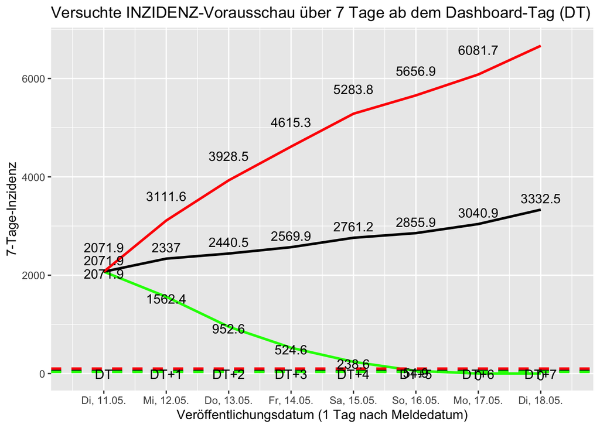

### Prognose der Fallzahlen

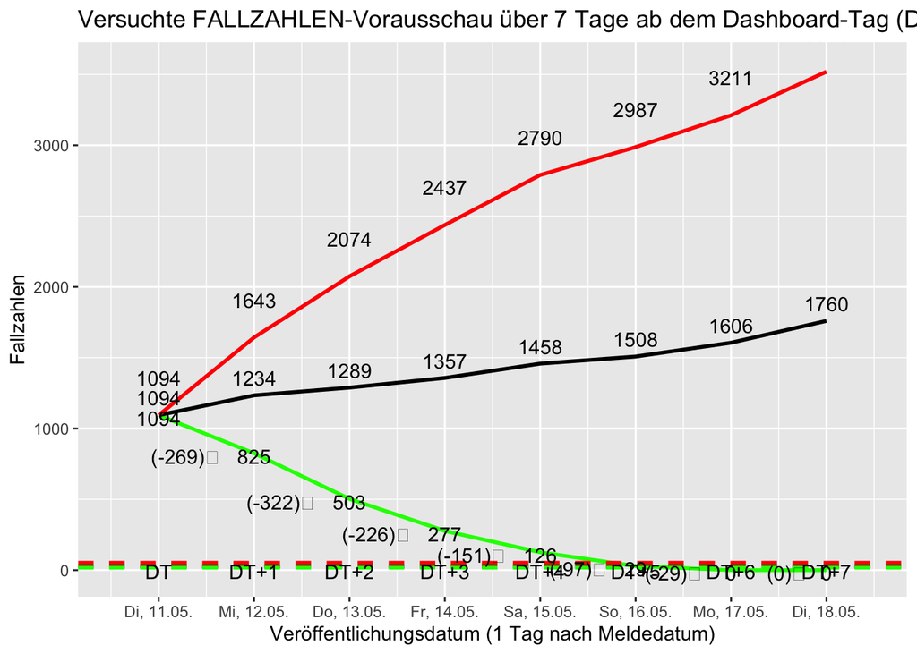